# Tugas Kelompok 9

Author

Kelompok 9

## Tim Kelompok 9

| Zainal Mu’arif | M0501261023 |
| --- | --- |
| Asiyah Safinatunnajah | M0501261010 |
| A. Rifkah Latifa Ilham | M0501261073 |

## Soal 1. Pembersihan Data Mahasiswa

### 1. Data Frame

```r
nilai_raw <- data.frame (
  Nama = c ("Andi", "Budi", "Citra", "Dewi", "Andi"),
  Matematika = c(80,90,NA,75,80),
  Statistika = c(85,88,78,"-",85),
  Umur = c(21,20,22,21,21)
)
nilai_raw
```

```
   Nama Matematika Statistika Umur
1  Andi         80         85   21
2  Budi         90         88   20
3 Citra         NA         78   22
4  Dewi         75          -   21
5  Andi         80         85   21
```

### 2. Identifikasi Nilai Hilang

```r
is.na(nilai_raw)
```

```
      Nama Matematika Statistika  Umur
[1,] FALSE      FALSE      FALSE FALSE
[2,] FALSE      FALSE      FALSE FALSE
[3,] FALSE       TRUE      FALSE FALSE
[4,] FALSE      FALSE      FALSE FALSE
[5,] FALSE      FALSE      FALSE FALSE
```

```r
colSums(is.na(nilai_raw))
```

```
      Nama Matematika Statistika       Umur
         0          1          0          0
```

```r
#Mengganti tanda - menjadi NA
nilai_raw$Statistika[nilai_raw$Statistika == "-"] <- NA
nilai_raw$Statistika <- as.numeric(nilai_raw$Statistika)
is.na(nilai_raw)
```

```
      Nama Matematika Statistika  Umur
[1,] FALSE      FALSE      FALSE FALSE
[2,] FALSE      FALSE      FALSE FALSE
[3,] FALSE       TRUE      FALSE FALSE
[4,] FALSE      FALSE       TRUE FALSE
[5,] FALSE      FALSE      FALSE FALSE
```

### 3. Imputasi Nilai Statistika yang Kosong

```r
#Imputasi Nilai NA dengan rata-rata
nilai_raw$Statistika[is.na(nilai_raw$Statistika)] <-
  mean(nilai_raw$Statistika, na.rm = TRUE)
nilai_raw
```

```
   Nama Matematika Statistika Umur
1  Andi         80         85   21
2  Budi         90         88   20
3 Citra         NA         78   22
4  Dewi         75         84   21
5  Andi         80         85   21
```

### 4. Buat Kolom Baru Status Umur

```r
nilai_raw$Status_Umur <- ifelse(nilai_raw$Umur >= 21, "Dewasa", "Muda")
nilai_raw
```

```
   Nama Matematika Statistika Umur Status_Umur
1  Andi         80         85   21      Dewasa
2  Budi         90         88   20        Muda
3 Citra         NA         78   22      Dewasa
4  Dewi         75         84   21      Dewasa
5  Andi         80         85   21      Dewasa
```

### 5. Menghapus Duplikat

```r
duplicated(nilai_raw)
```

```
[1] FALSE FALSE FALSE FALSE  TRUE
```

```r
nilai_bersih <- unique(nilai_raw)
nilai_bersih
```

```
   Nama Matematika Statistika Umur Status_Umur
1  Andi         80         85   21      Dewasa
2  Budi         90         88   20        Muda
3 Citra         NA         78   22      Dewasa
4  Dewi         75         84   21      Dewasa
```

### 6. Menyimpan Dataset

```r
write.csv(nilai_bersih, "nilai_bersih.csv", row.names = FALSE)
```

## Soal 2. Subsetting dan Pengurutan Multikriteria

### 1. Buat Data Frame Profil

```r
profil <- data.frame(
  No = 1:10,
  gender = c("f", "f", "f", "m", "m", "f", "m", "m", "f", "m"),
  v1 = c(8, 15, 8, 14, 8, 10, 9, 9, 10, 12),
  v2 = c(9, 8, 13, 9, 2, 6, 9, 10, 13, 10),
  v3 = c(5, 9, 12, 8, 9, 10, 7, 8, 6, 9),
  v4 = c(9, 5, 6, NA, 16, 9, 13, 10, 7, 8),
  v5 = c(9, 10, 7, 11, 8, 10, 9, 5, 10, 17),
  v6 = c(9, 8, 9, 10, 10, 10, 12, 10, 12, 7),
  v7 = c(5, 10, 14, 6, 8, 9, 10, 6, 13, 9),
  v8 = c(9, 12, 12, 11, 9, 7, 9, 12, 9, 10),
  v9 = c(11, 9, 12, 11, 8, 7, 11, 6, 6, 7),
  v10 = c(8, 15, 9, 8, 9, 11, 7, 8, 9, 7)
)
profil
```

```
   No gender v1 v2 v3 v4 v5 v6 v7 v8 v9 v10
1   1      f  8  9  5  9  9  9  5  9 11   8
2   2      f 15  8  9  5 10  8 10 12  9  15
3   3      f  8 13 12  6  7  9 14 12 12   9
4   4      m 14  9  8 NA 11 10  6 11 11   8
5   5      m  8  2  9 16  8 10  8  9  8   9
6   6      f 10  6 10  9 10 10  9  7  7  11
7   7      m  9  9  7 13  9 12 10  9 11   7
8   8      m  9 10  8 10  5 10  6 12  6   8
9   9      f 10 13  6  7 10 12 13  9  6   9
10 10      m 12 10  9  8 17  7  9 10  7   7
```

### 2. Subsetting

```r
profil_sub <- profil[
  (profil$gender == "m" & profil$v1 > 9) |
    (profil$gender == "f" & profil$v3 <= 10),
]
profil_sub
```

```
   No gender v1 v2 v3 v4 v5 v6 v7 v8 v9 v10
1   1      f  8  9  5  9  9  9  5  9 11   8
2   2      f 15  8  9  5 10  8 10 12  9  15
4   4      m 14  9  8 NA 11 10  6 11 11   8
6   6      f 10  6 10  9 10 10  9  7  7  11
9   9      f 10 13  6  7 10 12 13  9  6   9
10 10      m 12 10  9  8 17  7  9 10  7   7
```

### 3. Mengurutkan Data secara Multikriteria

```r
vec <- -profil_sub$v5
profil2 <- order(profil_sub$gender, vec, decreasing = TRUE)
profil_sub[profil2,]
```

```
   No gender v1 v2 v3 v4 v5 v6 v7 v8 v9 v10
4   4      m 14  9  8 NA 11 10  6 11 11   8
10 10      m 12 10  9  8 17  7  9 10  7   7
1   1      f  8  9  5  9  9  9  5  9 11   8
2   2      f 15  8  9  5 10  8 10 12  9  15
6   6      f 10  6 10  9 10 10  9  7  7  11
9   9      f 10 13  6  7 10 12 13  9  6   9
```

### 4. Menyimpan Hasil

```r
write.csv(
  profil_sub,
  "profil_filter.csv",
  row.names = FALSE
)
```

## Soal 3. Penggabungan dan Reshaping Data

### Buat Data Frame

```r
df_sales <- data.frame(
  id_toko = c("T1", "T2", "T3"),
  Minggu1 = c(120, 150, 95),
  Minggu2 = c(135, 140, 110)
)

df_info <- data.frame(
  id = c("T1", "T2", "T4"),
  Kota = c("Jakarta", "Bandung", "Surabaya")
)
```

### 1. Menggabungkan Kedua Data Frame

```r
data_gabung <- merge(
  df_sales,
  df_info,
  by.x = "id_toko",
  by.y = "id",
  all = TRUE
)

data_gabung
```

```
  id_toko Minggu1 Minggu2     Kota
1      T1     120     135  Jakarta
2      T2     150     140  Bandung
3      T3      95     110     <NA>
4      T4      NA      NA Surabaya
```

### 2. Mengubah Format Wide Menjadi Long

```r
data_long <- reshape(
  data_gabung,
  varying = c("Minggu1", "Minggu2"),
  v.names = "Penjualan",
  timevar = "Waktu",
  times = c("Minggu1", "Minggu2"),
  idvar = "id_toko",
  direction = "long"
)

rownames(data_long) <- NULL

data_long
```

```
  id_toko     Kota   Waktu Penjualan
1      T1  Jakarta Minggu1       120
2      T2  Bandung Minggu1       150
3      T3     <NA> Minggu1        95
4      T4 Surabaya Minggu1        NA
5      T1  Jakarta Minggu2       135
6      T2  Bandung Minggu2       140
7      T3     <NA> Minggu2       110
8      T4 Surabaya Minggu2        NA
```

### 3. Menyimpan Dataset

```r
write.csv(data_long, "penjualan_long.csv", row.names = FALSE)
```

## Soal 4. Eksplorasi Visual

### 1. Struktur Dataset

```r
library(tidyverse)
library(ggplot2)
```

```r
data(CO2)

# Melihat struktur dataset
str(CO2)
```

```
Classes 'nfnGroupedData', 'nfGroupedData', 'groupedData' and 'data.frame':  84 obs. of  5 variables:
 $ Plant    : Ord.factor w/ 12 levels "Qn1"<"Qn2"<"Qn3"<..: 1 1 1 1 1 1 1 2 2 2 ...
 $ Type     : Factor w/ 2 levels "Quebec","Mississippi": 1 1 1 1 1 1 1 1 1 1 ...
 $ Treatment: Factor w/ 2 levels "nonchilled","chilled": 1 1 1 1 1 1 1 1 1 1 ...
 $ conc     : num  95 175 250 350 500 675 1000 95 175 250 ...
 $ uptake   : num  16 30.4 34.8 37.2 35.3 39.2 39.7 13.6 27.3 37.1 ...
 - attr(*, "formula")=Class 'formula'  language uptake ~ conc | Plant
  .. ..- attr(*, ".Environment")=<environment: R_EmptyEnv>
 - attr(*, "outer")=Class 'formula'  language ~Treatment * Type
  .. ..- attr(*, ".Environment")=<environment: R_EmptyEnv>
 - attr(*, "labels")=List of 2
  ..$ x: chr "Ambient carbon dioxide concentration"
  ..$ y: chr "CO2 uptake rate"
 - attr(*, "units")=List of 2
  ..$ x: chr "(uL/L)"
  ..$ y: chr "(umol/m^2 s)"
```

```r
summary(CO2)
```

```
     Plant             Type         Treatment       conc          uptake
 Qn1    : 7   Quebec     :42   nonchilled:42   Min.   :  95   Min.   : 7.70
 Qn2    : 7   Mississippi:42   chilled   :42   1st Qu.: 175   1st Qu.:17.90
 Qn3    : 7                                    Median : 350   Median :28.30
 Qc1    : 7                                    Mean   : 435   Mean   :27.21
 Qc3    : 7                                    3rd Qu.: 675   3rd Qu.:37.12
 Qc2    : 7                                    Max.   :1000   Max.   :45.50
 (Other):42
```

```r
glimpse(CO2)
```

```
Rows: 84
Columns: 5
$ Plant     <ord> Qn1, Qn1, Qn1, Qn1, Qn1, Qn1, Qn1, Qn2, Qn2, Qn2, Qn2, Qn2, …
$ Type      <fct> Quebec, Quebec, Quebec, Quebec, Quebec, Quebec, Quebec, Queb…
$ Treatment <fct> nonchilled, nonchilled, nonchilled, nonchilled, nonchilled, …
$ conc      <dbl> 95, 175, 250, 350, 500, 675, 1000, 95, 175, 250, 350, 500, 6…
$ uptake    <dbl> 16.0, 30.4, 34.8, 37.2, 35.3, 39.2, 39.7, 13.6, 27.3, 37.1, …
```

Berdasarkan hasil dataset diketahui bahwa Dataset `CO2` terdiri dari 84 baris observasi dan 5 variabel utama. Variabel pertama adalah `Plant` yang merupakan faktor terurut dengan 12 level atau identitas tanaman berbeda, di mana setiap tanaman tercatat memiliki 7 data observasi. Variabel kedua dan ketiga yaitu `Type` dan `Treatment` merupakan variabel faktor dengan masing-masing 2 level; `Type` menunjukkan wilayah asal tanaman (Quebec dan Mississippi), sedangkan `Treatment` menyatakan perlakuan suhu yang diberikan (nonchilled dan chilled), dengan jumlah sebaran data yang terbagi rata masing-masing 42 baris untuk setiap kategorinya.

Selanjutnya, terdapat dua variabel numerik yaitu `conc` dan `uptake`. Variabel `conc` merepresentasikan konsentrasi karbon dioksida ambien (dalam uL/L) yang memiliki rentang nilai dari 95 hingga 1000. Sementara itu, variabel `uptake` menyatakan tingkat laju penyerapan CO2 (dalam umol/m^2 s) dengan rentang nilai dari 7.70 hingga 45.50.

[figure not shown]

```r
# 1. Buat grafik utama terlebih dahulu
plot(
  CO2$conc,
  CO2$uptake,
  pch = 19,
  cex = 1.2,
  col = ifelse(CO2$Type == "Quebec","steelblue", "lightgreen"),
  main = "Hubungan Konsentrasi CO2 dan Uptake",
  xlab = "Konsentrasi CO2 (conc)",
  ylab = "Penyerapan CO2 (uptake)",
  xlim = c(0, 1050),
  ylim = c(0, 50)
)

# 2. Menghitung rata-rata uptake setiap conc
rata_co2 <- aggregate(
  uptake ~ conc,
  data = CO2,
  FUN = mean
)

# 3. Tambahkan titik rata-rata
points(
  rata_co2$conc,
  rata_co2$uptake,
  pch = 18,
  cex = 1.5,
  col = "black"
)

# 4. Tambahkan garis
lines(
  rata_co2$conc,
  rata_co2$uptake,
  lwd = 2,
  col = "black"
)

# 5. Tambahkan legenda
legend(
  "bottomright",
  legend = c("Nonchilled", "Chilled", "Rata-rata"),
  col = c("steelblue", "lightgreen", "black"),
  pch = c(19, 19, 18),
  bty = "n"
)
```

### 2. Tampilan Grafik 2x2 dengan 4 Jenis Visualisasi

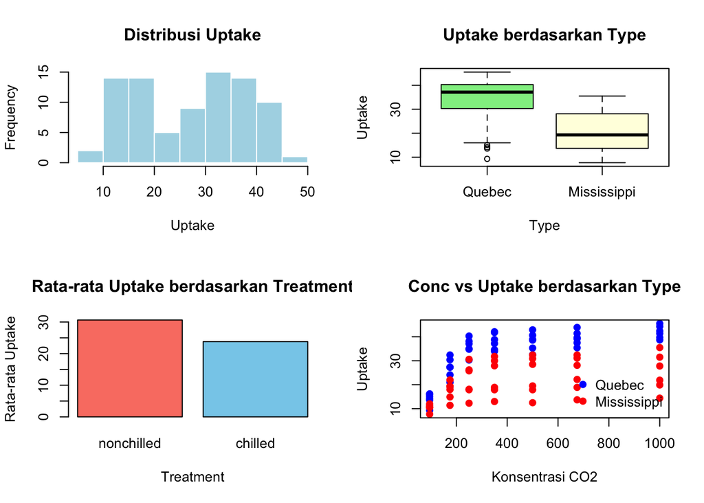

```r
par(mfrow = c(2, 2))

#Grafik 1
hist(
  CO2$uptake,
  main = "Distribusi Uptake",
  xlab = "Uptake",
  col = "lightblue",
  border = "white"
)

#Grafik 2
boxplot(
  uptake ~ Type,
  data = CO2,
  main = "Uptake berdasarkan Type",
  xlab = "Type",
  ylab = "Uptake",
  col = c("lightgreen", "lightyellow")
)

#Grafik 3
mean_treatment <- aggregate(
  uptake ~ Treatment,
  data = CO2,
  FUN = mean
)

barplot(
  mean_treatment$uptake,
  names.arg = mean_treatment$Treatment,
  main = "Rata-rata Uptake berdasarkan Treatment",
  xlab = "Treatment",
  ylab = "Rata-rata Uptake",
  col = c("salmon", "skyblue")
)

#Grafik 4
plot(
  CO2$conc,
  CO2$uptake,
  pch = 19,
  col = ifelse(CO2$Type == "Quebec", "blue", "red"),
  main = "Conc vs Uptake berdasarkan Type",
  xlab = "Konsentrasi CO2",
  ylab = "Uptake"
)

legend(
  "bottomright",
  legend = c("Quebec", "Mississippi"),
  col = c("blue", "red"),
  pch = 19,
  bty = "n"
)
```

Visualisasi di atas terdiri dari empat jenis plot. Penggunaan Histogram berfungsi untuk melihat pola sebaran data `uptake` secara keseluruhan, sementara Boxplot dan Barplot digunakan untuk membandingkan perbedaan nilai `uptake` berdasarkan kategori wilayah (`Type`) dan perlakuan suhu (`Treatment`).

Selain itu, Scatter Plot digunakan untuk melihat pola hubungan atau korelasi antara konsentrasi CO2 (`conc`) terhadap `uptake` yang dibedakan berdasarkan wilayah asalnya. Melalui kombinasi plot-plot ini, kita dapat melihat bagaimana sebaran, perbedaan kategori, serta hubungan antar variabel bekerja di dalam dataset `CO2`

### 3. QPlot dan GGPlot

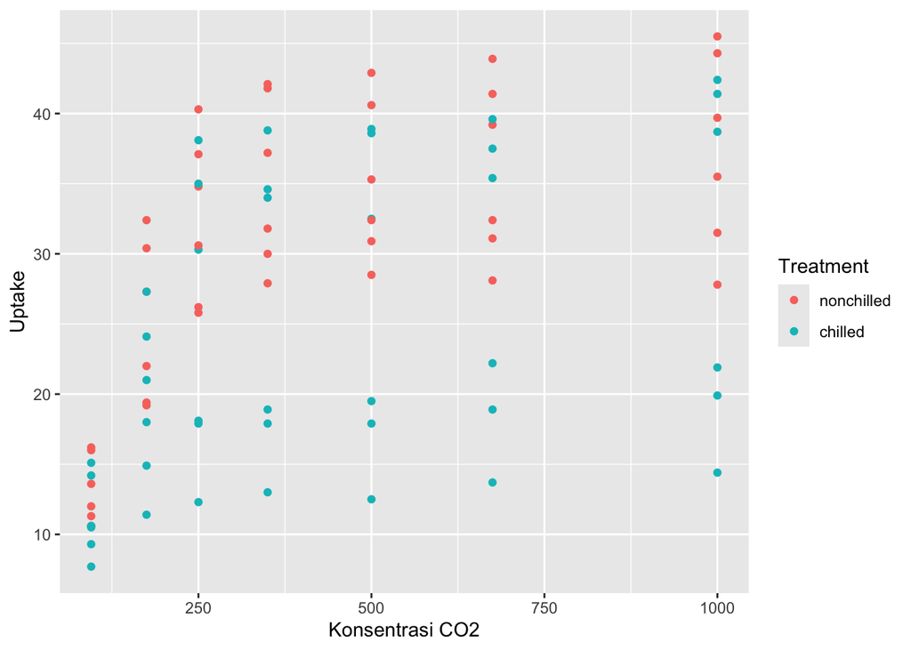

```r
#QPlot
qplot(conc, uptake, data = CO2, color = Treatment,
      xlab = "Konsentrasi CO2", ylab = "Uptake")
```

Grafik dari qplot memetakan hubungan antara konsentrasi CO2 (conc) dan tingkat penyerapan (uptake) dengan membedakan titik-titik data berdasarkan perlakuan suhu (Treatment). Berdasarkan grafik tersebut, terlihat bahwa titik-titik berwarna merah untuk perlakuan nonchilled cenderung berada di posisi yang lebih tinggi dibandingkan titik biru untuk perlakuan chilled. Hal ini mengindikasikan bahwa tanaman yang tidak diberi perlakuan dingin secara umum memiliki laju penyerapan CO2 yang lebih tinggi pada berbagai tingkat konsentrasi dibandingkan tanaman yang didinginkan.

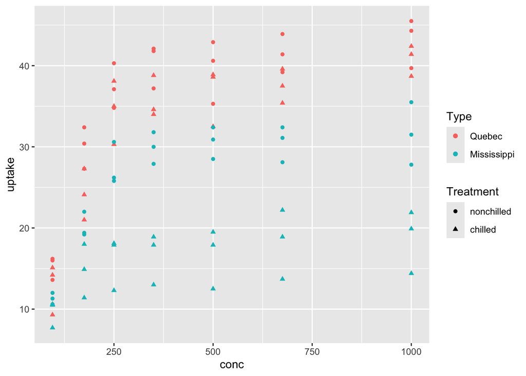

```r
#GGPlot
ggplot(CO2,
       aes(x = conc,
           y = uptake,
           col = Type,
           shape = Treatment)) +
  geom_point()
```

Grafik dari ggplot menyajikan informasi yang jauh lebih komprehensif karena melibatkan dua variabel pembeda sekaligus, yaitu wilayah asal tanaman (type) melalui warna titik dan perlakuan suhu (treatment) melalui bentuk simbol. Melalui grafik ini, terlihat interaksi yang lebih mendalam di mana tanaman asal Quebec mendominasi bagian atas grafik dengan penyerapan yang lebih tinggi, sementara tanaman Mississippi terkonsentrasi di bagian bawah.

### 4. Pengembangan Grafik GGPlot

[output not shown]

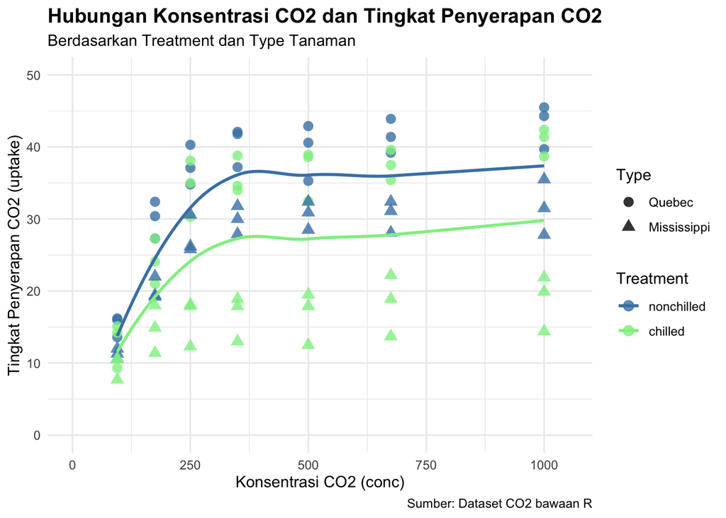

```r
p_final <- ggplot(
  CO2,
  aes(
    x = conc,
    y = uptake,
    color = Treatment,
    shape = Type
  )
) +

  geom_point(
    size = 3,
    alpha = 0.8
  ) +

  stat_smooth(
    aes(group = Treatment),
    method = "loess",
    se = FALSE,
    linewidth = 1
  ) +

  scale_color_manual(
    values = c(
      "chilled" = "lightgreen",
      "nonchilled" = "steelblue"
    )
  ) +

  coord_cartesian(
    xlim = c(0, 1050),
    ylim = c(0, 50)
  ) +

  labs(
    title = "Hubungan Konsentrasi CO2 dan Tingkat Penyerapan CO2",
    subtitle = "Berdasarkan Treatment dan Type Tanaman",
    x = "Konsentrasi CO2 (conc)",
    y = "Tingkat Penyerapan CO2 (uptake)",
    color = "Treatment",
    shape = "Type",
    caption = "Sumber: Dataset CO2 bawaan R"
  ) +

  theme_minimal() +

  theme(
    plot.title = element_text(
      face = "bold",
      size = 14
    ),
    legend.position = "right"
  )

p_final
```

### 5. Menyimpan Grafik Akhir

```r
ggsave("co2_uptake_visualisasi.png",
       width = 7,
       height = 5,
       dpi = 300)
```

**NoteInterpretasi Grafik Akhir**

A. Pengaruh Konsentrasi terhadap Penyerapan

Fase peningkatan awal pada konsentrasi CO2 rendah (100), tingkat penyerapan seluruh tanaman berada di titik terendah (sekitar 7–16). Ketika konsentrasi CO2 dinaikkan hingga kisaran 250–350, terjadi lonjakan penyerapan yang sangat curam pada semua kelompok tanaman.Terdapat titik jenuh memasuki rentang konsentrasi 500 hingga 1000, kurva tren garis biru maupun hijau mulai melandai. Hal ini menunjukkan bahwa kapasitas fotosintesis tanaman telah mencapai batas maksimalnya, sehingga penambahan konsentrasi CO2 yang lebih tinggi tidak lagi menghasilkan peningkatan penyerapan yang signifikan.

B. Pengaruh Perlakuan Suhu (Treatment: Nonchilled vs Chilled)

Adanya dampak negatif suhu dingin, terdapat perbedaan warna garis menunjukkan deviasi yang sangat jelas. Garis biru (nonchilled) berada jauh di atas garis hijau (chilled). Perlakuan suhu dingin terbukti menurunkan kapasitas fotosintesis tanaman secara drastis. Tanaman chilled mengalami hambatan metabolik atau kerusakan pada enzim yang terlibat dalam fiksasi karbon, sehingga kemampuan menyerap CO2 jauh lebih rendah dibandingkan tanaman normal (nonchilled).

C. Pengaruh Asal Wilayah Tanaman (Type: Quebec vs Mississippi)

Terdapat pengaruh adaptasi iklim lokal, jika diamati dari sebaran bentuk simbol di dalam kelompok warna yang sama, Tanaman Quebec (Lingkaran) secara konsisten mendominasi bagian atas grafik, mencatatkan angka uptake yang lebih tinggi. Sedangkan Tanaman Mississippi (Segitiga) cenderung terkonsentrasi di bagian bawah pada setiap kategori perlakuan suhu. Hal ini mengindikasikan adanya adaptasi genetik atau perbedaan varietas tumbuhan (Echinochloa crus-galli) terhadap lingkungan asal mereka, di mana populasi asal Quebec menunjukkan performa fotosintesis yang lebih tangguh pada kondisi eksperimen ini.

D. Kesimpulan

Plot ini menunjukkan bahwa penyerapan CO2 oleh tanaman sangat dipengaruhi secara bersama-sama oleh ketersediaan gas CO2 (yang memiliki batas jenuh), kondisi suhu lingkungan (suhu dingin menekan efisiensi penyerapan), serta faktor genetik/asal geografis tanaman itu sendiri.